# Using AscRtain: Body Text

Under the Hood Documentation

Following Groenwold et al. (2019) we can calculate the biased OR for a binary exposure $(A)$ on a binary outcome $(Y)$ when both influence the probability of being present in the sample $(S)$.

Let us assume that being present in the sample is conditional on these two binary traits. Then we may express an individual’s chance of being present in the sample as constituted of four probabilities:

$$\mathbb{P}(S=1|A,Y)=β_0+β_AA+β_YY+β_{AY}AY$$

Where:

$\beta_0$ is the baseline probability of any individual to be a part of our sample. In order for any generalisation to be made, this needs to be non-zero, otherwise sampling is solely a function of the exposure and outcome.

$\beta_A$ is the differential probability of being sampled for individuals in the exposed group $(A=1)$.

$\beta_Y$ is the differential probability of being sampled for cases $(Y=1)$.

$\beta_{AY}$ is the differential probability of being sampled for cases in the exposed group $(A=1,Y=1)$.

Given this, we may derive the expected odds ratio, which gives:

$$E[\widehat{OR}_{S=1}]=\dfrac{β_0(β_0+β_A+β_Y+β_{AY})}{(β_0+β_A)(β_0+β_Y)}$$

For the purposes of the parameter_space() function, we want to know for given fraction of population sampled $(pS)$, and known prevalence of outcome and sampling, what parameter space of possible selection effects would give rise to a given odds ratio $(OR)$ under a true null effect $(OR=1)$.

Thus, for the purposes of sensitivity analyses, we are solely interested in the $β$ parameter values that approximately give rise to our specified value of $pS$:

$$pS=β_0+β_Ap_A+β_Yp_Y+β_{AY}p_{AY}$$

Substituting in known values of $p_A$, $p_Y$ and $p_{AY}$ allows us to calculate $pS$ for a given $\beta_0$, $\beta_A$, $\beta_Y$ and $\beta_{AY}$. We then take all $\beta_*$ combinations which satisfy our $pS$ conditions, and calculate $E[\widehat{OR}_{S=1}]$ for all combinations. We can then present the combination of $\beta_*$ estimates which give rise to the bounds of $pS$ and the observed $OR$.

For any given $\beta_*$ values, we can simulate independent exposure and outcome data under selection pressures, and we should recapitulate our observed $OR$.

A simplified demonstration of this method is provided below. For a version of the example below taken directly from the literature see our preprint. For simplicity we omit discussion of the $\beta_{AY}$ interaction term here.

### Smoking and COVID-19: A worked example

Let’s take an example from the literature that emerged around smoking and COVID in the early stages of the pandemic, a [preprint](https://www.preprints.org/manuscript/202004.0540/v1) detailing a meta-analysis of 18 published studies of smoking and COVID-19 reported an OR for current smoking and hospitalisation of 0.17 (95% CI 0.13-0.21) amongst Chinese studies.

We have written explainers on why inferring from relationships from hospitalised patients may be subject to collider bias [[1](https://www.hdruk.ac.uk/news/we-should-be-cautious-about-associations-of-patient-characteristics-with-covid-19-outcomes-that-are-identified-in-hospitalised-patients/),[2](https://rss.onlinelibrary.wiley.com/doi/10.1111/1740-9713.01413)]. For the purposes of explanation here, let’s assume that there is no interaction between the selection processes for smoking and COVID-19 into a hospitalised sample. That is, the selection forces acting on an individual who both smokes and has COVID-19 are equal to the sum of their constituent $\beta$ estimates.

### AscRtain Input

We can then input this into `AscRtain` for a binary collider structure using the `parameter_space()` function.

First we must initialise a new VBB (**V**-structure, **B**inary-exposure, **B**inary-outcome) structure

```r
library(AscRtain)
x <- VBB$new
x
```

```
#> <VBB>
#>   Public:
#>     clone: function (deep = FALSE)
#>     histogram: function (bins = 30)
#>     or_calc: function (b0, ba, by, bay)
#>     param: NULL
#>     parameter_space: function (target_or, pS, pA, pY, pAY, b0_range, ba_range, by_range,
#>     ps_calc: function (b0, ba, by, bay, pA, pY, pAY)
#>     scatter: function ()
#>     scatter3d: function (ticktype = "detailed", theta = 130, phi = 0, bty = "g",
```

We can calculate an $OR$ if we input $\beta_*$ estimates.

```r
x$or_calc(b0=0.1, ba=0.5, by=0.5, bay=0.2)
```

```
#> [1] 0.3611111
```

Now for given target odds ratio, we wish to explore whether the observed result could be explained solely by sample ascertainment. For this we use the `AscRtain::parameter_space()` function.

`parameter_space()` takes 10 arguments, which are as follows:

`target_or` is the observed $OR$.  
`pS` is the proportion of the target population in the sample **P(S=1)**.  
`pA` is the proportion of the population who are in the exposed group **P(A=1)**.  
`pY` is the proportion of the cases in the population **P(Y=1)**.  
`pAY` is the proportion of the population who are both exposed *and* cases **P(A=1, Y=1)**.  
`b0_range` is the range of $\beta_0$ values we want to explore.  
`ba_range` is the range of $\beta_A$ values we want to explore.  
`bay_range` is the range of $\beta_{AY}$ values we want to explore.  
`granularity` is the resolution of the $\beta_*$ ranges we wish to explore (default is 100).

For the result we suspect may be the result of an ascertained sample, we can input known population values.

```r
x$parameter_space(
  target_or= 0.17,
  pS=0.01,
  pA=0.277,
  pY=0.1,
  pAY=0.0277,
  b0_range=c(0,0.2),
  ba_range=c(-0.1, 0.2),
  by_range=c(-0.1,0.2),
  bay_range=c(0,0),
  granularity=200
)
```

```
#> 8000000 parameter combinations
#> 41784 within pS_tol
#> 762 beyond OR threshold
```

Which parameter values for selection effects give rise to an OR at least as extreme as 0.17 under a true null effect.

```r
x$param
# A tibble: 762 x 9
```

```
#>      pA    pY    pAY     b0        ba       by   bay     ps1       or
#>   <dbl> <dbl>  <dbl>  <dbl>     <dbl>    <dbl> <dbl>   <dbl>    <dbl>
#> 1 0.277   0.1 0.0277 0.0131 -0.000503 -0.0126      0 0.0117  7.18e-15
#> 2 0.277   0.1 0.0277 0.0131 -0.00201  -0.0111      0 0.0114  2.04e-15
#> 3 0.277   0.1 0.0277 0.0131 -0.00352  -0.00955     0 0.0111  1.35e-15
#> 4 0.277   0.1 0.0277 0.0151 -0.00653  -0.00804     0 0.0125  1.26e- 1
#> 5 0.277   0.1 0.0277 0.0131 -0.00503  -0.00804     0 0.0109  5.61e-15
#> 6 0.277   0.1 0.0277 0.0101 -0.00201  -0.00804     0 0.00869 8.63e-15
#> 7 0.277   0.1 0.0277 0.0151 -0.00804  -0.00653     0 0.0122  1.26e- 1
#> 8 0.277   0.1 0.0277 0.0131 -0.00653  -0.00653     0 0.0106  5.31e-15
#> 9 0.277   0.1 0.0277 0.0121 -0.00503  -0.00653     0 0.0100  1.56e- 1
#> 10 0.277   0.1 0.0277 0.0101 -0.00352  -0.00653     0 0.00842 6.07e-15
```

```r
# ... with 752 more rows
```

We can see that there are many values of $\beta_A$ and $\beta_Y$ which meet the target odds ratio. In order to get a feel for these, let’s visualise them.

```r
x$scatter()
```

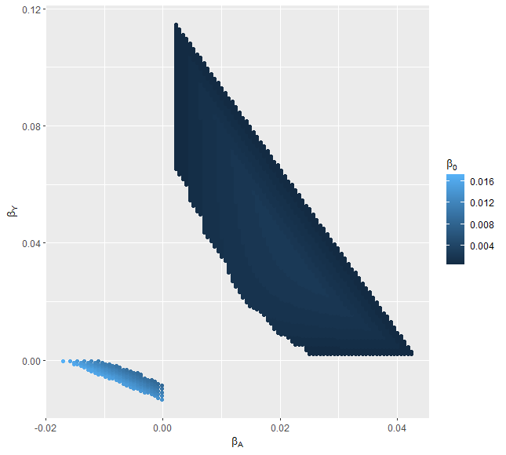

We can see from the scatter plot above, that with relatively subtle changes in selection effects, we can produce extreme ORs. This example has excluded the possibility of the interactive effect on sample membership of both COVID-19 and smoking status, but this further complicates matters. There is a more comprehensive discussion of this in the medrxiv [preprint](https://www.medrxiv.org/content/10.1101/2020.05.04.20090506v3) that accompanies this app.

### Simulate from parameter values to recapitulate target OR.

We want to simulate individual level data in which there is no relationship between **A** and **Y**. Note that actual population size is not relevant here, it is the proportion of the population sampled that matters.

Parameters:

```r
a <- subset(x$param, by==max(abs(by)))[1,]
a
# A tibble: 1 x 9
```

```
#>     pA    pY    pAY       b0      ba    by   bay    ps1    or
#>  <dbl> <dbl>  <dbl>    <dbl>   <dbl> <dbl> <dbl>  <dbl> <dbl>
#> 1 0.277   0.1 0.0277 0.000401 0.00220 0.115     0 0.0125 0.157
```

Simulate from parameters:

```r
set.seed(1337)
n <- 1000000
Y <- rbinom(n, 1, a$pY)
A <- rbinom(n, 1, a$pA)
pS <- a$b0 + a$ba * A + a$by * Y
S <- rbinom(n, 1, pS)
```

What proportion of the population **n** are present in our sample **S**?

```r
sum(S) / length(S)
```

```
#> [1] 0.012493
```

From our simulated population, what is the observed assocation between A and Y in the sampled subset?

```r
summary(glm(Y~A, family="binomial", subset=S==1))$coef[2,1] %>% exp
```

```
#> [1] 0.1264771
```

Compare this to our expected biased association from `x$param`:

```r
a$or
```

```
#> [1] 0.157
```

We can see that the OR is beyond the target OR that we specified in our research question. Thus we see an OR at least as extreme as our target OR within our sample, solely as a result of selection effects. In this case, if the baseline probability of being in the sample is 0.0004, and smoking increases this by 0.0022, whilst COVID-19 increases this by 0.115, we can find an OR of 0.157 for smoking on COVID-19 caseness, when the true relationship in the population is null.